# 19_tangent_get_adjacent

## 19_tangent_get_adjacent

#### Question

1. A right triangle has an angle of 0.67 radians. The opposite leg has a length of 27 meters. How long, in meters, is the leg adjacent the angle?

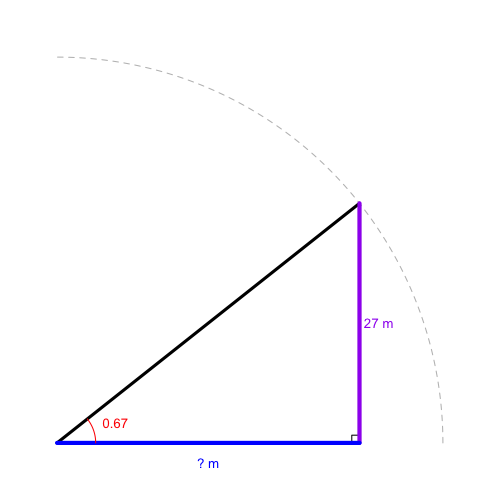

   Please round your answer to the nearest meter.

#### Question

2. A right triangle has an angle of 0.94 radians. The opposite leg has a length of 73 meters. How long, in meters, is the leg adjacent the angle?

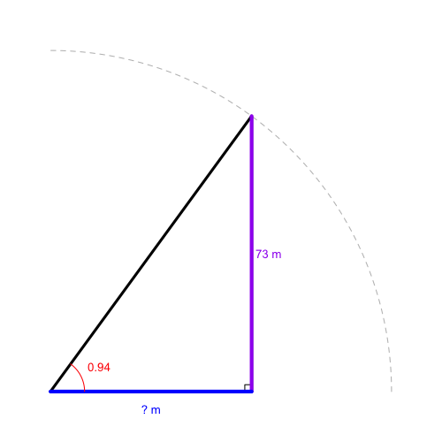

   Please round your answer to the nearest meter.

#### Question

3. A right triangle has an angle of 0.62 radians. The opposite leg has a length of 52 meters. How long, in meters, is the leg adjacent the angle?

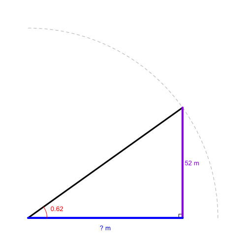

   Please round your answer to the nearest meter.

#### Question

4. A right triangle has an angle of 1.25 radians. The opposite leg has a length of 65 meters. How long, in meters, is the leg adjacent the angle?

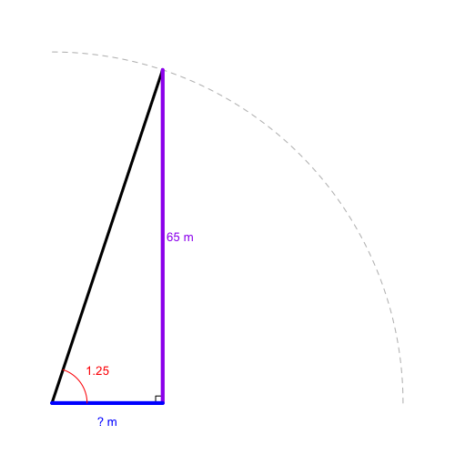

   Please round your answer to the nearest meter.

#### Question

5. A right triangle has an angle of 0.62 radians. The opposite leg has a length of 16 meters. How long, in meters, is the leg adjacent the angle?

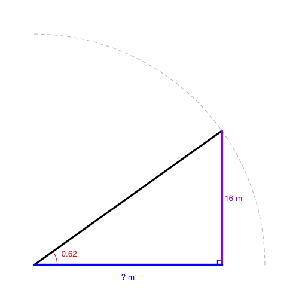

   Please round your answer to the nearest meter.

#### Question

6. A right triangle has an angle of 1.03 radians. The opposite leg has a length of 39 meters. How long, in meters, is the leg adjacent the angle?

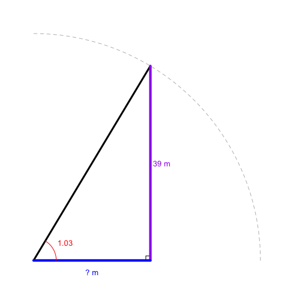

   Please round your answer to the nearest meter.

#### Question

7. A right triangle has an angle of 1.10 radians. The opposite leg has a length of 49 meters. How long, in meters, is the leg adjacent the angle?

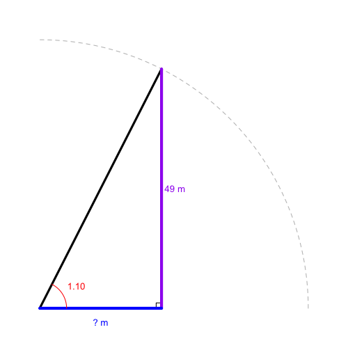

   Please round your answer to the nearest meter.

#### Question

8. A right triangle has an angle of 1.06 radians. The opposite leg has a length of 85 meters. How long, in meters, is the leg adjacent the angle?

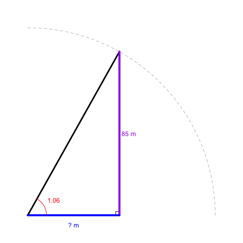

   Please round your answer to the nearest meter.